# Exemple de simulation pour explorer la prédiction génomique

Timothée Flutre (INRAE), Charlotte Brault

13/02/2023

Abstract

Ce document a pour but de montrer un exemple de prédiction génomique à partir de données simulées.

# 1 Contexte

Ce document fait partie de l’atelier “Prédiction Génomique” organisé et animé par Jacques David, Vincent Segura, Charlotte Brault, Marie Serrie, Sarah Bensadoun, Théo Leprevost, Friedrich Longin, Charlotte Brault, Julie Fievet et Marion Gauthier à [Montpellier SupAgro](http://www.supagro.fr) dans le cadre de l’option [APIMET](http://www.agro-montpellier.fr/web/pages/?idl=19&page=216&id_page=630) (Amélioration des Plantes et Ingénierie végétale Méditerranéennes et Tropicales) couplée à la spécialité SEPMET (Semences Et Plants Méditerranéens Et Tropicaux) du [Master 3A](http://www.supagro.fr/web/pages/?idl=19&page=1689) (Agronomie et Agroalimentaire), la spécialisation [PIST](http://www.agroparistech.fr/Production-et-innovation-dans-les,1633.html) du [Cursus Ingénieur](http://www.agroparistech.fr/Cursus-ingenieurs.html) d’[AgroparisTech](http://www.agroparistech.fr/) et la spécialité d’amélioration des plantes de l’Institut Agro de Rennes.

Le copyright appartient à Montpellier SupAgro et à l’Institut National de la Recherche Agronomique. Le contenu du répertoire est sous license [Creative Commons Attribution-ShareAlike 4.0 International](http://creativecommons.org/licenses/by-sa/4.0/). Veuillez en prendre connaissance et vous y conformer (contactez les auteurs en cas de doute).

Les versions du contenu sont gérées avec le logiciel git, et le dépôt central est hébergé sur [GitHub](https://github.com/jacquesdavid/SELGEN2021).

Il est recommandé d’avoir déjà lu attentivement les documents “Premiers pas” et “Prédiction génomique” de l’atelier.

# 2 Installation et chargement des paquets R

```r
# Le paquet anyLib permet d'installer les paquets si nécessaire
# install.packages("anyLib")
suppressPackageStartupMessages(library(anyLib))
# anyLib(pkg=c("rrBLUP","cvTools","devtools","scrm",
#              "adegenet","rutilstimflutre", "RCurl","GenomicRanges"))
# devtools::install_github("scrm/scrm-r")
suppressPackageStartupMessages(library(rrBLUP))
suppressPackageStartupMessages(library(cvTools))
suppressPackageStartupMessages(library(devtools))
suppressPackageStartupMessages(library(apercu))
```

Un certain niveau de déséquilibre de liaison entre génotypes aux SNP est indispensable pour obtenir une précision de prédiction suffisamment élevée en validation croisée. Pour cela, on peut utiliser le processus du coalescent avec recombinaison. Une bonne approximation de celui-ci est implémenté dans le paquet scrm. Par ailleurs, afin de tracer le déséquilibre de liaison en fonction de la distance physique, il vous faut aussi le paquet GenomicRanges de Bioconductor. Afin de faciliter l’utilisation de ces paquets dans ce document, il vous faut aussi avoir mon paquet de travail, rutilstimflutre, disponible sur GitHub.

```r
suppressPackageStartupMessages(library(scrm))
if (!requireNamespace("BiocManager", quietly = TRUE))
    install.packages("BiocManager")

# BiocManager::install("GenomicRanges")
suppressPackageStartupMessages(library(GenomicRanges))
suppressPackageStartupMessages(library(rutilstimflutre))
suppressPackageStartupMessages(library(adegenet))
```

Si l’installation de `rutilstimflutre` pose problème, vous pouvez utiliser un condensé de ses fonctions en chargeant le fichier source `rutils_like.R`.

Sourcer le fichier `rutils_like.R`, aller sur le GitHub de Jacques David (https://github.com/jacquesdavid/SELGEN2021), puis dans le répertoire **Approche_par_simulation**, cliquer sur le fichier “rutils_like.R” et copier le code (onglet **raw**) dans un nouveau script R.

- Option 1 : aller dans l’onglet rutils_like.R dans Rstudio et cliquer sur le bouton “Source”
- Option 2 : appliquer la fonction “source” en mettant le chemin d’accès vers ce script R.

Vérifier que les fonctions sont bien chargées dans l’environnement.

```r
#source("/rutils_like.R", encoding = "UTF-8")
```

Il est également utile de savoir combien de temps est nécessaire pour exécuter tout le code R de ce document (voir l’annexe):

```r
t0 <- proc.time()
```

# 3 Modèle

En se limitant à une architecture additive infinitésimale:

$$\begin{align*}
\boldsymbol{y} &= \boldsymbol{1} \, \mu + X \, \boldsymbol{\beta} +
\boldsymbol{\epsilon} \\
&= \boldsymbol{1} \, \mu + \boldsymbol{a} + \boldsymbol{\epsilon}
\end{align*}$$

avec:

- $\boldsymbol{\epsilon} \sim \mathcal{N}_N(\boldsymbol{0}, \sigma^2 \, \text{Id})$;
- $\boldsymbol{\beta} \sim \mathcal{N}_P(\boldsymbol{0}, \sigma_\beta^2 \, \text{Id})$;
- $\boldsymbol{a} \sim \mathcal{N}_N(\boldsymbol{0}, \sigma_a^2 \, A_{\text{mark}})$ avec $A_{\text{mark}} = \frac{X X^T}{2 \sum_{p} f_p (1 - f_p)}$.

Cet estimateur de $A_{\text{mark}}$ est décrit dans [Habier et coll. (2007)](http://dx.doi.org/10.1534/genetics.107.081190), mais un meilleur estimateur, centré, est proposé dans [VanRaden (2008)](http://dx.doi.org/10.3168/jds.2007-0980): pour plus de détails, lire [Toro et coll. (2011)](http://www.gsejournal.org/content/43/1/27) et [Vitezica et coll. (2013)](http://dx.doi.org/10.1534/genetics.113.155176).

# 4 Simulation des données

```r
set.seed(111)
```

## 4.1 Simulation des génotypes

Pour simuler une structure, on peut utiliser une fonction de Timothée Flutre (rutilstimflutre) : `SimulCoalescent`.

Voici un exemple de code pour appliquer cette fonction, disponible sur [Github](https://github.com/timflutre/rutilstimflutre/blob/master/misc/simul-pop-struct.Rmd)

### 4.1.1 Génotypes aux SNP

Paramètres du Coalescent qui vont déterminer l’histoire génétique des individus simulés.

```r
nb.genos <- 500 # nombre de génotypes
nb.chroms <- 5 # nombre de chromosomes
Ne <- 10^4 # taille efficace
chrom.len <- 5*10^5 # longueur de chaque chromosome
mu <- 10^(-8) # taux de mutation
c.rec <- 10^(-8) # taux de recombinaison
```

#### 4.1.1.1 Coalescent séquentiel avec recombinaison **sans** structure

Une population sans structure est une population uniforme, avec des apparentements génétiques similaires entre tous les individus.

```r
genomes <- simulCoalescent(nb.inds=nb.genos, nb.reps=nb.chroms,
                           pop.mut.rate=4 * Ne * mu * chrom.len,
                           pop.recomb.rate=4 * Ne * c.rec * chrom.len,
                           chrom.len=chrom.len,
                           #mig.rate=5, # => valeur par défaut sans structure
                           nb.pops=1,
                           verbose=1)
```

```
## simulate according to the SCRM ...
## scrm 1000 5 -t 200 -r 200 5e+05 -SC abs -oSFS
## nb of SNPs: 7210
## chr1 chr2 chr3 chr4 chr5
## 1404 1366 1474 1546 1420
## make a data.frame with SNP coordinates ...
## randomize haplotypes to make diploid genotypes ...
## convert haplotypes into genotypes encoded as allele dose ...
## permute alleles in haplotypes ...
## permute alleles in genotypes ...
```

```r
dim(genomes$genos)
```

```
## [1]  500 7210
```

```r
genomes$genos[1:8,1:8]
```

```
##        snp0001 snp0002 snp0003 snp0004 snp0005 snp0006 snp0007 snp0008
## ind001       2       2       2       2       2       1       2       2
## ind002       2       2       2       2       2       1       2       2
## ind003       2       2       2       2       2       1       2       2
## ind004       2       2       2       2       2       1       2       2
## ind005       2       2       2       2       2       0       2       2
## ind006       2       2       2       2       2       0       2       2
## ind007       2       2       2       2       2       0       2       2
## ind008       2       2       2       2       2       0       2       2
```

#### 4.1.1.2 Coalescent séquentiel avec recombinaison et **avec** structure

La structure est ici simulée avec des taux de migration : plus le taux de migration est faible, plus les populations seront différenciées entre elles.

```r
mig.rates <- 10^-4 # faible migration => forte structure
nb.pops <- 3 # nombre de populations (+/- différenciées)
chrom.len <- 10^5
nb.genos2 <- 300

genomes.struct <- simulCoalescent(nb.inds=nb.genos2,
                                  nb.reps=nb.chroms,
                                  pop.mut.rate=4 * Ne * mu * chrom.len,
                                  pop.recomb.rate=4 * Ne * c.rec * chrom.len,
                                  chrom.len=chrom.len,
                                  nb.pops=nb.pops,
                                  mig.rate=4*Ne*mig.rates,
                                  verbose=1)
```

```
## simulate according to the SCRM ...
## scrm 600 5 -t 40 -r 40 1e+05 -I 3 200 200 200 4 -SC abs -oSFS
## nb of SNPs: 4409
## chr1 chr2 chr3 chr4 chr5
##  803  937  900  923  846
## make a data.frame with SNP coordinates ...
## randomize haplotypes to make diploid genotypes ...
## convert haplotypes into genotypes encoded as allele dose ...
## permute alleles in haplotypes ...
## permute alleles in genotypes ...
```

```r
dim(genomes.struct$genos)
```

```
## [1]  300 4409
```

```r
genomes.struct$genos[1:8,1:8]
```

```
##        snp0001 snp0002 snp0003 snp0004 snp0005 snp0006 snp0007 snp0008
## ind001       0       0       0       2       0       2       1       0
## ind002       0       0       0       2       0       2       1       0
## ind003       0       0       0       2       0       2       1       0
## ind004       0       0       0       2       0       2       1       0
## ind005       0       0       0       2       0       2       1       0
## ind006       0       0       0       2       0       2       1       0
## ind007       0       0       0       2       0       1       1       0
## ind008       0       0       0       2       0       2       1       0
```

### 4.1.2 Echantillonnage des SNP

On sous-échantillonne des SNP parmi les bases du génome simulées

```r
dim(genomes$genos)
```

```
## [1]  500 7210
```

```r
dim(genomes.struct$genos)
```

```
## [1]  300 4409
```

```r
P <- 1000 # nombre de SNP à échantillonner
# on s'assure d'abord qu'il y a assez de marqueurs
stopifnot(ncol(genomes.struct$genos) >= P,
          ncol(genomes$genos) >= P)
# sans structure
idx.snps.tokeep <- sample.int(n=ncol(genomes$genos), size=P, replace=FALSE)
X <- genomes$genos[, idx.snps.tokeep]
# avec structure
idx.snps.tokeep <- sample.int(n=ncol(genomes.struct$genos), size=P, replace=FALSE)
X.struct <- genomes.struct$genos[, idx.snps.tokeep]

dim(X)
```

```
## [1]  500 1000
```

```r
X[1:8, 1:8]
```

```
##        snp6682 snp3581 snp2585 snp1768 snp2736 snp1275 snp1507 snp5494
## ind001       2       1       0       0       0       2       2       2
## ind002       1       0       0       0       0       2       2       2
## ind003       2       0       0       0       1       0       2       0
## ind004       2       0       0       0       1       2       2       2
## ind005       2       1       0       0       2       1       2       2
## ind006       2       0       0       0       0       2       2       2
## ind007       2       1       0       0       0       1       2       1
## ind008       2       0       0       0       0       1       2       2
```

```r
snp.coords <- genomes$snp.coords[colnames(X),]
#rm(genomes)
```

### 4.1.3 Visualisation de la structure

Représentation graphique de la structure

```r
# par(mfrow=c(1,1))
# graphics.off()
A.nostruct <- estimGenRel(X=X, verbose=0)
ap(as.matrix(A.nostruct))
```

```
##          ind001 ind002  ind003  ind004   ind005
## ind001  1.04281  0.031 -0.0265 -0.1489  0.00162
## ind002  0.03099  1.002 -0.1615 -0.1085 -0.19436
## ind003 -0.02649 -0.161  0.9782 -0.0211 -0.04596
## ind004 -0.14893 -0.109 -0.0211  1.1069 -0.13790
## ind005  0.00162 -0.194 -0.0460 -0.1379  1.17924
```

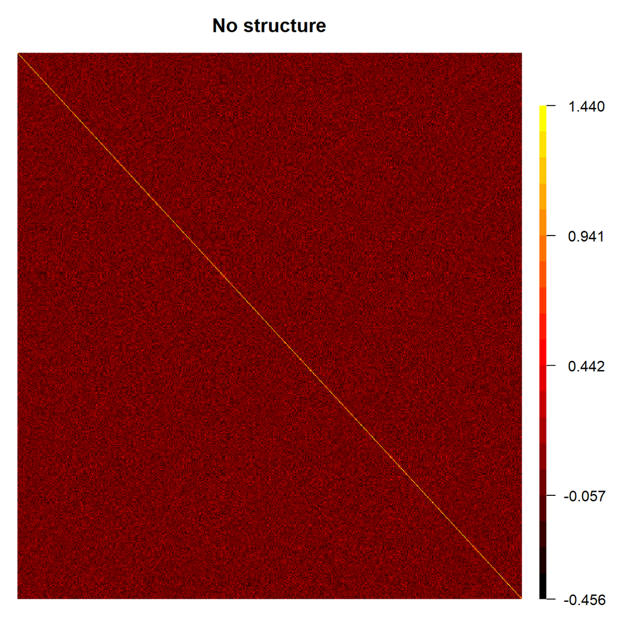

```r
#graphics.off()
imageWithScale(A.nostruct, main="No structure")
```

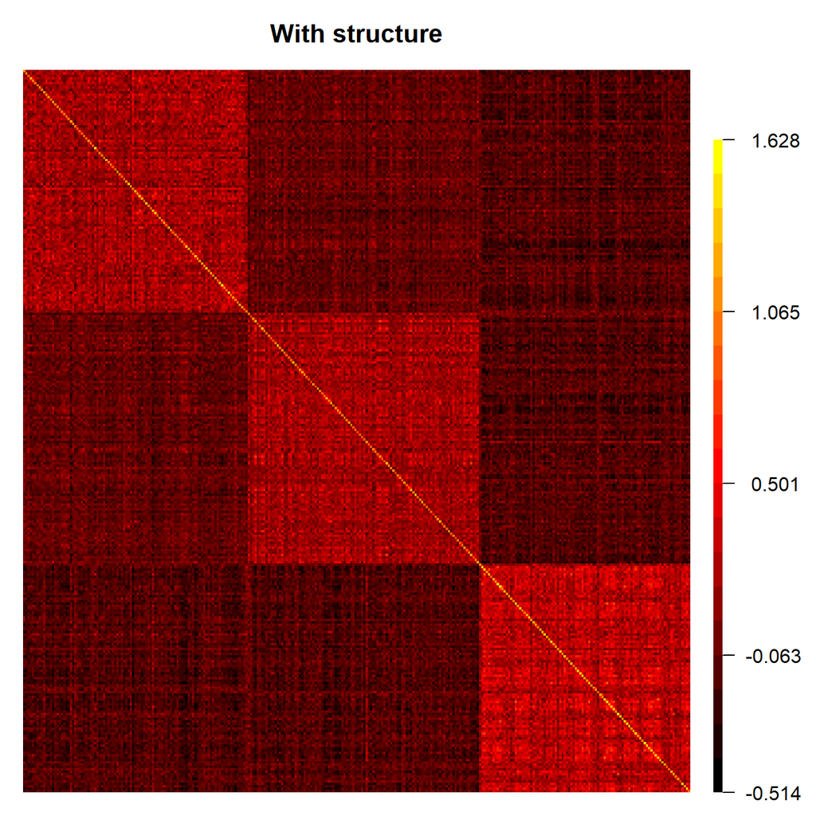

```r
rm(A.nostruct)
A.struct <- estimGenRel(X=X.struct, verbose=0)
imageWithScale(A.struct, main="With structure")
```

```r
rm(A.struct)
#graphics.off()
```

Affichage des groupes de structure génétique avec une **Analyse en Composantes Principales**.

```r
# Sans structure
out.pca.nostruct <- pca(X=X)
out.pca.nostruct$prop.vars[1:4]
```

```
##    PC1    PC2    PC3    PC4
## 0.0343 0.0263 0.0260 0.0245
```

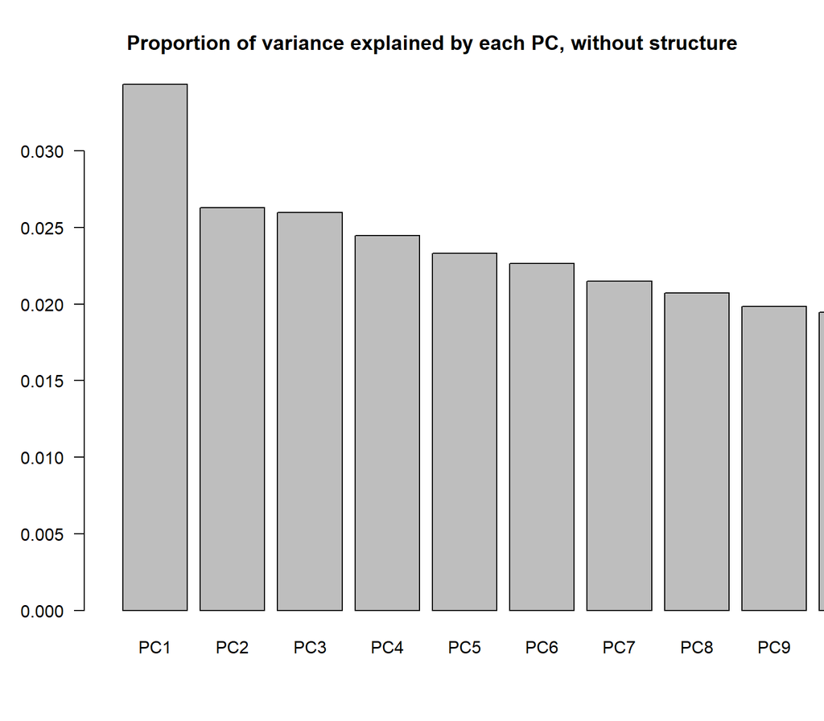

```r
barplot(out.pca.nostruct$prop.vars[1:10],
        main="Proportion of variance explained by each PC, without structure",
        xlim=c(0,10), las=1)
```

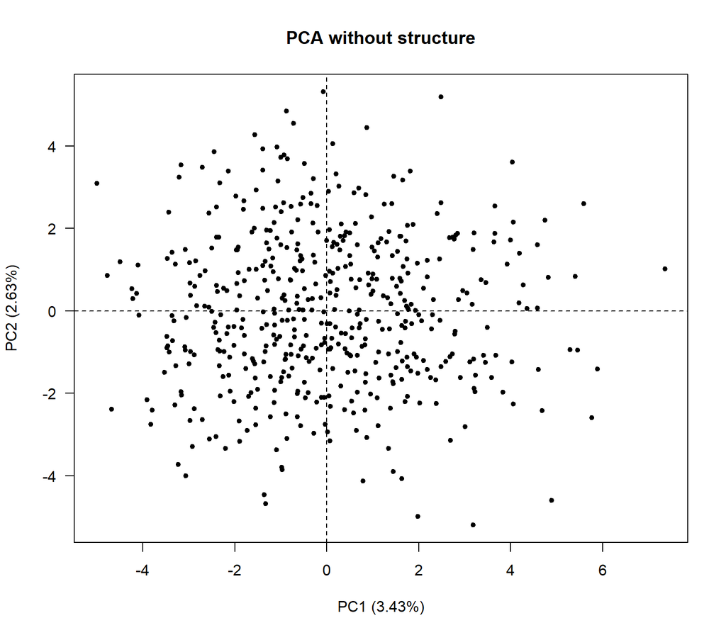

```r
plotPca(rotation=out.pca.nostruct$rot.dat,
        prop.vars=out.pca.nostruct$prop.vars,
        main="PCA without structure")
```

```r
# Avec structure
out.pca.struct <- pca(X=X.struct)
out.pca.struct$prop.vars[1:4]
```

```
##    PC1    PC2    PC3    PC4
## 0.1347 0.0894 0.0356 0.0331
```

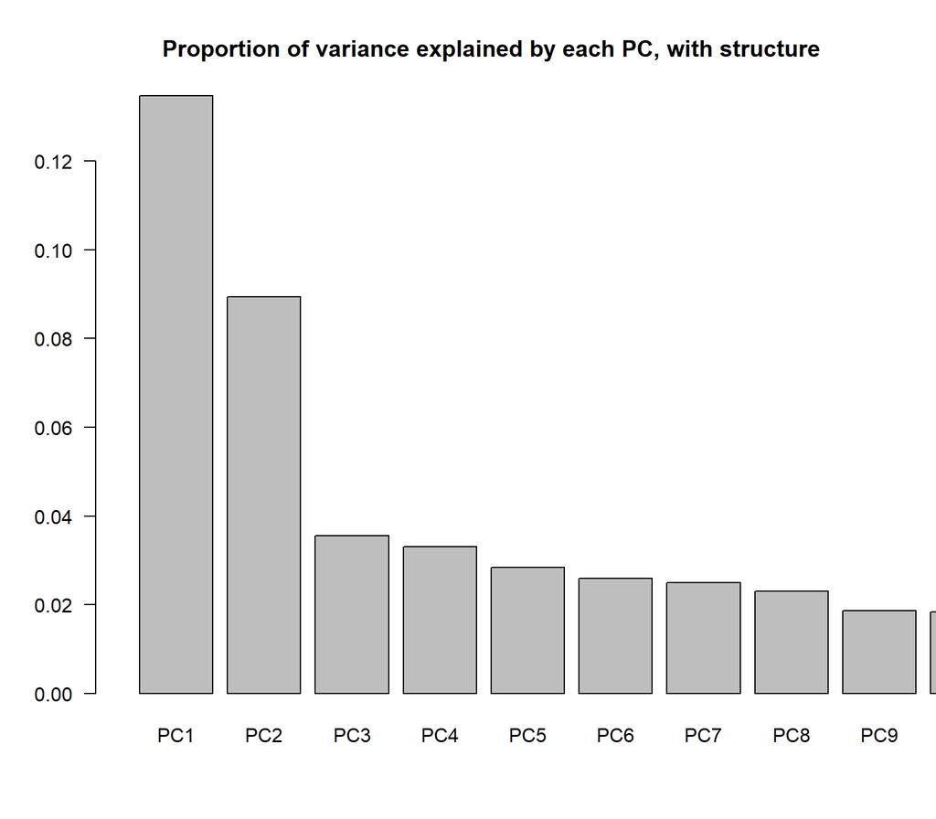

```r
barplot(out.pca.struct$prop.vars,
        main="Proportion of variance explained by each PC, with structure",
        xlim=c(0,10), las=1)
```

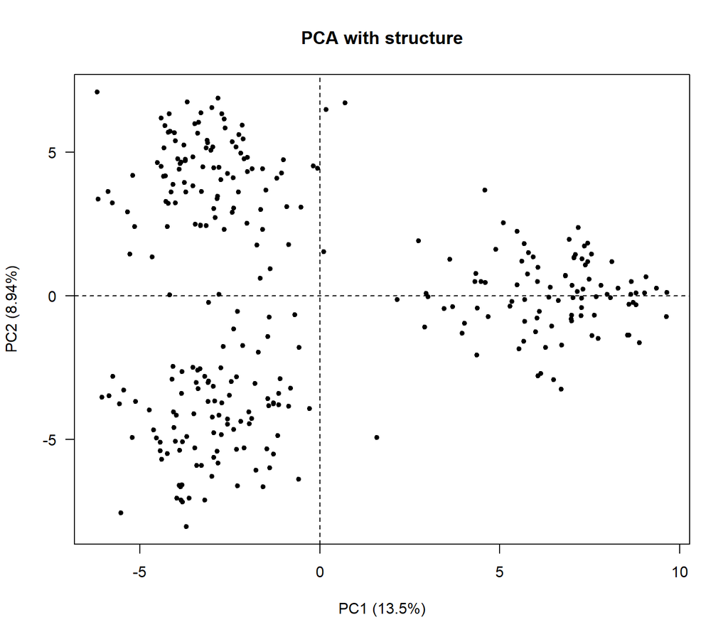

```r
plotPca(rotation=out.pca.struct$rot.dat,
        prop.vars=out.pca.struct$prop.vars,
        main="PCA with structure")
```

## 4.2 Distinction des sous-population

Une des problématiques en prédiction génomique est la distance génétique entre la population d’entraînement, qui a servi à ajuster le modèle (c’est-à-dire à estimer les effets associés aux marqueurs $\hat \beta$). Si la population est structurée, alors il y a de la distance génétique entre les différentes sous-populations. Vous pourrez voir comment évolue la précision de prédiction lorsque la population de validation fait partie d’une sous-population différente de la population d’entraînement.

```r
sub_pop <- find.clusters(x=X.struct, n.pca=2, scale=TRUE, method="kmeans",
                         choose.n.clust=TRUE, n.clust=3)
levels(sub_pop$grp)
```

```
## [1] "1" "2" "3"
```

```r
sub_pop$size
```

```
## [1] 104  95 101
```

## 4.3 Simulation des phénotypes

### 4.3.1 Effets additifs des SNP

On peut simuler 2 types d’architecture génétique :

- Modèle infinitésimal : chaque marqueur a un effet faible sur le phénotype.
- Modèle oligogénique : certains marqueurs à effet nuls et certains à effet non nul (SNP causal).

```r
nb_QTL <- P # modèle infinitésimal
## nb_QTL <- 5 # modèle oligogénique
sigma.beta2 <- 10^(-3) # choisi arbitrairement, variance effet marqueur
# échantillonnage des marqueurs à effet non nul (QTL)
QTL <- sample(P, nb_QTL)
# effet associé au marqueur égal à 0
beta <- rep(0, P)
# pour les QTL, effet tiré dans une loi normale
beta[QTL] <- rnorm(n=nb_QTL, mean=0, sd=sqrt(sigma.beta2))
# centrage et réduction pour avoir variance et moyenne comparables
beta <- scale(beta, center=TRUE, scale=TRUE)
```

On obtient un vecteur $\beta$ des vrais effets des marqueurs.

### 4.3.2 Valeurs génotypiques additives et variance génétique additive

Ici on a gardé la matrice des génotypes aux marqueurs issue de la simulation **sans structure**. Notez que $X$ est initialement codé en $\{0,1,2\}$, mais que dans la suite on peut le centrer à l’aide des fréquences alléliques comme dans l’estimateur de VanRaden:

```r
N <- nb.genos # nombre d'individus
afs <- colMeans(X) / 2 # fréquence allélique
tmp <- matrix(rep(1, N)) %*% (2 * afs)
# centrage sur les fréquences alléliques
X.center <- X - tmp
```

Les vraies valeurs génétiques additives ($a$) sont définies comme suit : $a = X \beta$

```r
# Vecteur des valeurs génétiques additives vraies = true breeding values
a <- X.center %*% beta
# Variance génétique additive
(sigma.a2 <- 1  * 2 * sum(afs * (1 - afs)))
```

```
## [1] 131
```

### 4.3.3 Erreurs

```r
h2 <- 0.7 # héritabilité au sens strict
(sigma2 <- ((1 - h2) / h2) * sigma.a2) # variance d'erreur calculée à partir de h^2 et de sigma.a2
```

```
## [1] 56.2
```

```r
epsilon <- rnorm(n=N, mean=0, sd=sqrt(sigma2)) # vecteur d'erreurs
```

### 4.3.4 Phénotypes

Le vecteur des phénotypes correspond à la formule : $y = \mu + X\beta + \epsilon$. Nous avons simulé $X$, $\beta$, $\epsilon$. Il reste à déterminer $\mu$ (moyenne du caractère) pour calculer $y$.

```r
mu <- 36 # chosen arbitrarily
y <- mu + X.center %*% beta + epsilon
summary(y)
```

```
##        V1
##  Min.   :-10.1
##  1st Qu.: 25.8
##  Median : 35.6
##  Mean   : 35.0
##  3rd Qu.: 44.9
##  Max.   : 75.0
```

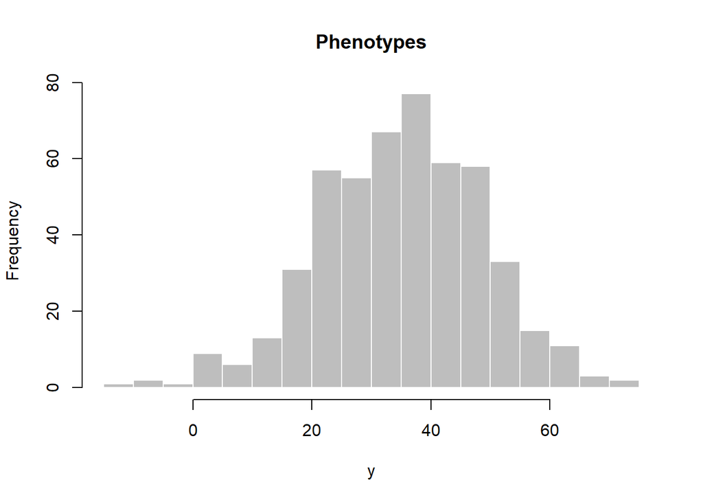

```r
hist(y, breaks="FD", main="Phenotypes", col="grey", border="white")
```

# 5 Description des données simulées

## 5.1 Fréquences alléliques

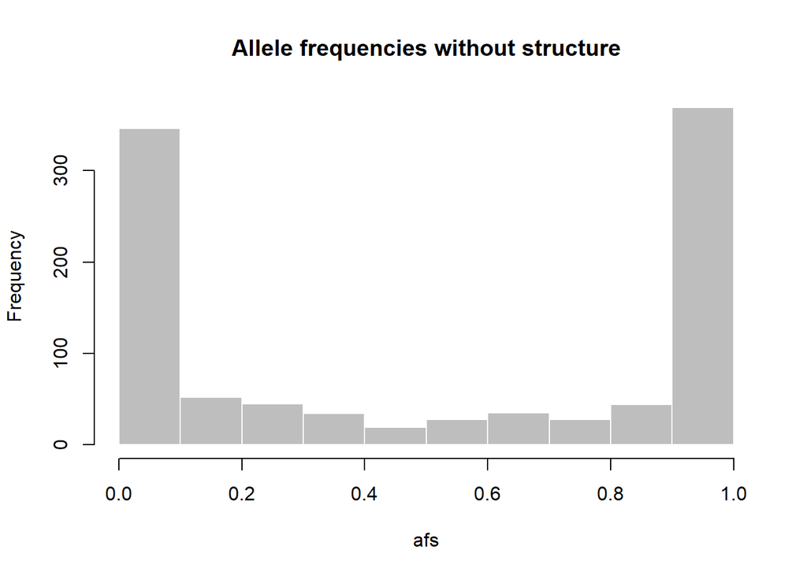

```r
afs <- colMeans(X) / 2
hist(afs, xlim=c(0, 1), main="Allele frequencies without structure", col="grey", border="white")
```

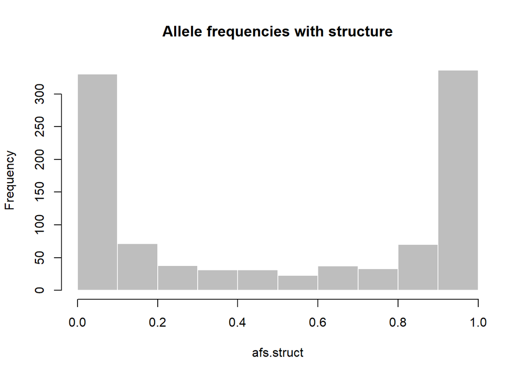

```r
afs.struct <- colMeans(X.struct) / 2
hist(afs.struct, xlim=c(0, 1), main="Allele frequencies with structure", col="grey", border="white")
```

## 5.2 Relations génétiques additives

Estimateur de Habier et coll. (2007):

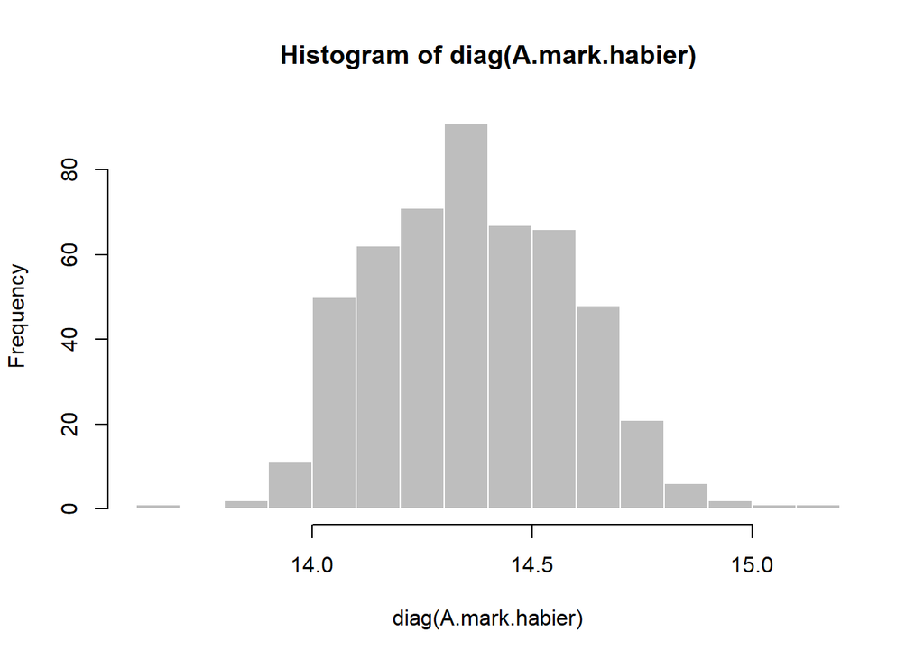

```r
A.mark.habier <- (X %*% t(X)) / (2 * sum(afs * (1 - afs)))
hist(diag(A.mark.habier), breaks="FD",col="grey", border="white")
```

Estimateur de VanRaden (2008):

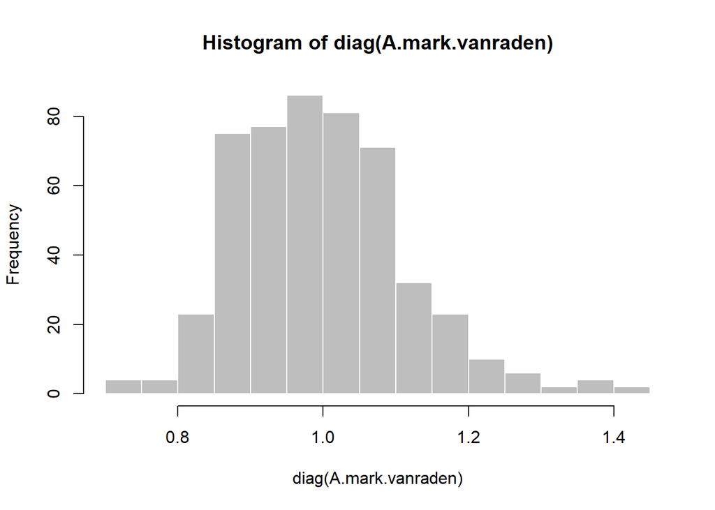

```r
A.mark.vanraden <- (X.center %*% t(X.center)) / (2 * sum(afs * (1 - afs)))
hist(diag(A.mark.vanraden), breaks="FD",col="grey", border="white")
```

## 5.3 Déséquilibre de liaison

```
## extract relevant genotypes and SNPs...
## estimate pairwise LD...
```

```
## make GRanges ...
```

```
## calculate pairwise distances ...
```

```
## extract relevant genotypes and SNPs...
## estimate pairwise LD...
```

```
## make GRanges ...
## calculate pairwise distances ...
```

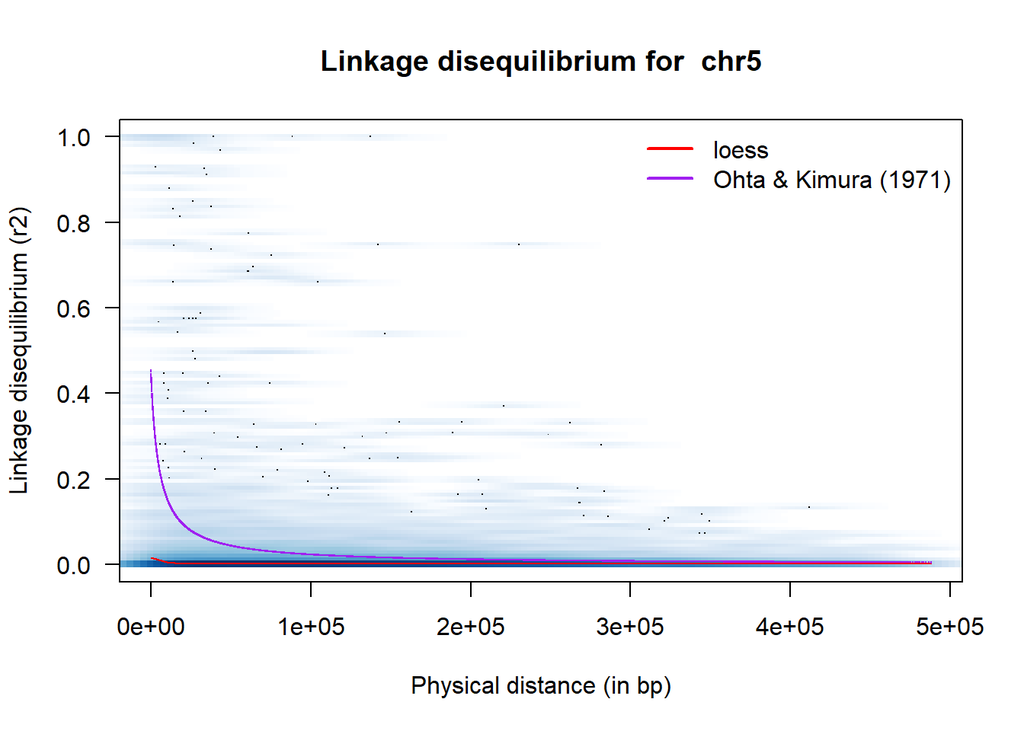

```
## extract relevant genotypes and SNPs...
## estimate pairwise LD...
```

```
## make GRanges ...
## calculate pairwise distances ...
```

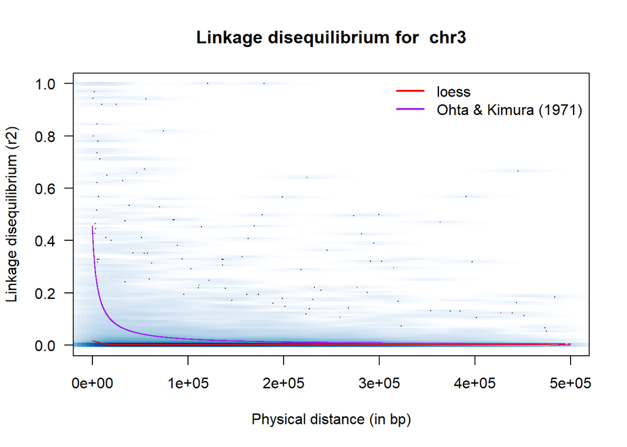

```
## extract relevant genotypes and SNPs...
## estimate pairwise LD...
```

```
## make GRanges ...
## calculate pairwise distances ...
```

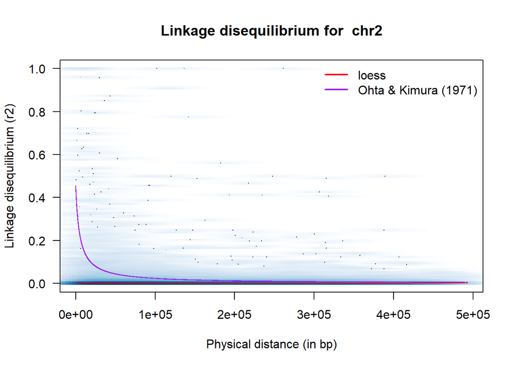

```
## extract relevant genotypes and SNPs...
## estimate pairwise LD...
```

```
## make GRanges ...
## calculate pairwise distances ...
```

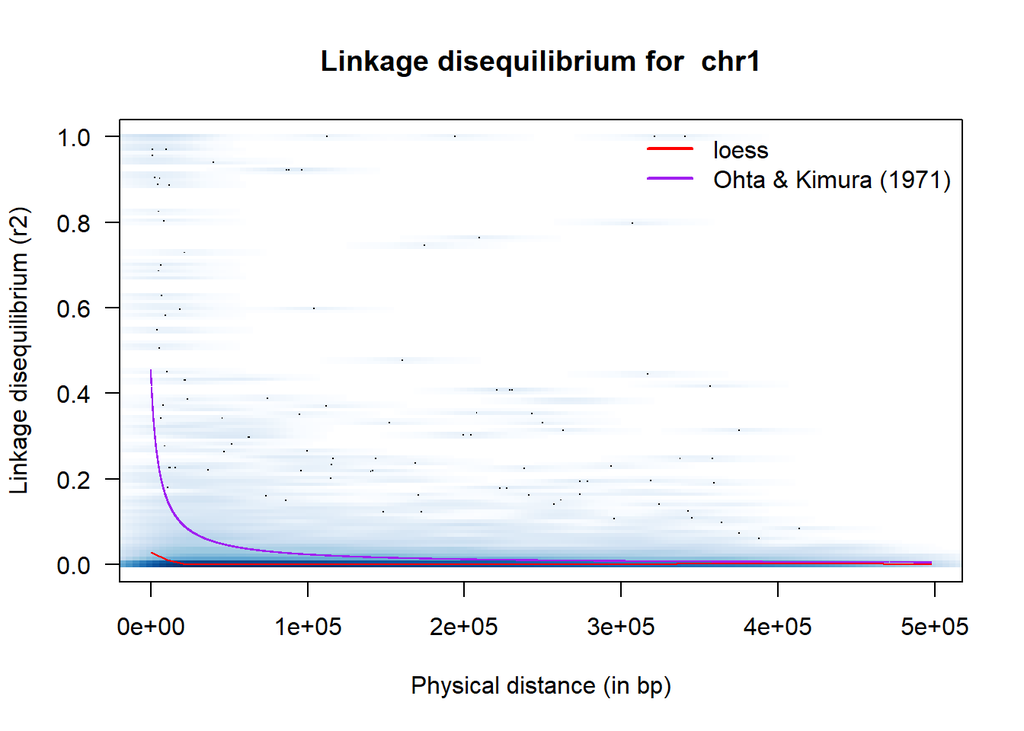

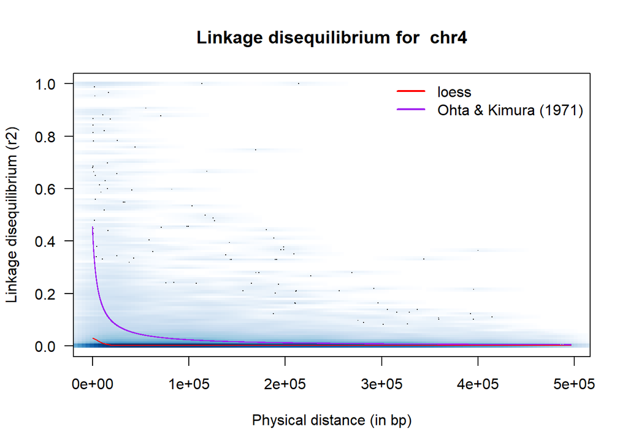

```r
## X correspond à la matrice génotypique pour les SNP échantillonnés
for(chr in unique(snp.coords$chr)){
  LD <- estimLd(X=X, snp.coords = snp.coords, only.chr =chr)
  LD$dist <- distSnpPairs(data.frame(loc1=LD$loc1, loc2=LD$loc2),
                          genomes$snp.coords,
                          nb.cores = 1, verbose = 1)

  plotLd(x=LD$dist, y=LD$cor2, xlab="Physical distance (in bp)",
         main=paste("Linkage disequilibrium for ", chr),
         add.ohta.kimura=TRUE, Ne=Ne, c=c.rec)
}
```

# 6 Sauvegarde des données

Pour tester différents paramètres, vous pouvez sauvegarder à ce stade les données simulées et faire tourner la sélection génomique par validation croisée à part. Pour sauvegarder les objets sous forme de liste dans R, on peut utiliser la fonction `save`et enregistrer le fichier sous format `.Rdata`. La fonction pour charger le fichier est `load`.

Exemple pour sauvegarder les données ensemble sous la forme d’une liste :

```r
save_list <- list(
  ## complétez par vos paramètres !
  ###
  param.h2=h2,
  param.struct="nostruct",
  ###
  y.pheno=y,
  X.geno=X.center
)
##save(save_list, file.choose()) # ne pas oublier l'extension .Rdata
```

Pour accéder au fichier sauvegardé :

```r
# load(file.choose()) # choisir le bon fichier, il aura le même nom que la liste enregistrée
# y <- save_list$y.pheno
# X <- save_list$X.center
```

# 7 Sélection génomique

## 7.1 Evaluation pour une partition

Pour évaluer la qualité de notre modèle et l’influence des paramètres de simulation, nous allons utiliser la validation croisée. l’ensemble des génotypes ($X$) et des phénotypes ($y$) va être divisé en ensembles d’entraînement et de test: $X_{train}, y_{train}$ et $X_{test}, y_{test}$ .

Le modèle de prédiction va être ajusté sur l’ensemble d’entraînement pour estimer les effets associés aux marqueurs ($\hat\beta$), puis ces effets des marqueurs vont être utilisés pour prédire des nouveaux génotypes, comme dans la vraie vie, en appliquant $\hat y_{test} = X_{test} \hat \beta$. Puisque nous avons accès aux phénotypes de l’ensemble de validation, nous pouvons vérifier la qualité de prédiction en faisant la corrélation entre la valeur prédite ($\hat y_{test}$) et la valeur “observée” ($y_{test}$)

### 7.1.1 Définition des ensembles d’entraînement et de test

Création de vecteurs logiques (TRUE / FALSE) pour indiquer quels individus sont contenus dans la population d’entrainement et lesquels sont dans la population de validation. Pour l’exemple, on fait ici un ajustement du modèle sur les individus du jeu d’entraînement (`in.train`), on compare les effets estimés avec la simulation et on prédit sur les individus du jeu de validation (`in.test`).

Dans la pratique, on utilise des fonctions de **validation croisée** qui vont, pour chaque partition, estimer directement la qualité de la prédiction sur le jeu de validation.

```r
prop <- 0.8
in.train <- sample(c(TRUE,FALSE), size=N, replace=TRUE, prob=c(prop, 1-prop))
sum(in.train)
```

```
## [1] 404
```

```r
in.test <- (! in.train)
sum(in.test)
```

```
## [1] 96
```

```r
stopifnot(xor(in.train, in.test)) # vérification que chaque individu est soit dans l'ensemble d'entrainement, soit dans l'ensemble de validation
```

### 7.1.2 Entraînement

Ajuster le modèle avec la méthode de **ridge regression** :

```r
fit <- rrBLUP::mixed.solve(y=y[in.train], Z=X[in.train,])
str(fit)
```

```
## List of 5
##  $ Vu  : num 1.05
##  $ Ve  : num 57.8
##  $ beta: num [1(1d)] 42.9
##  $ u   : num [1:1000(1d)] 0.704 0.431 -0.116 0.125 0.866 ...
##   ..- attr(*, "dimnames")=List of 1
##   .. ..$ : chr [1:1000] "snp6682" "snp3581" "snp2585" "snp1768" ...
##  $ LL  : num -1539
```

Comparer les estimations des paramètres avec les valeurs utilisées pour simuler les données:

```r
# Moyenne
mu.hat <- fit$beta
c(mu, mu.hat)
```

```
## [1] 36.0 42.9
```

```r
# Variance génétique
sigma.beta2.hat <- fit$Vu
c(1, sigma.beta2.hat)
```

```
## [1] 1.00 1.05
```

```r
# Variance d'erreur
sigma2.hat <- fit$Ve
c(sigma2, sigma2.hat)
```

```
## [1] 56.2 57.8
```

```r
# Variance génétique additive
sigma.a2.hat <- sigma.beta2.hat * 2 * sum(afs * (1 - afs))
c(sigma.a2, sigma.a2.hat)
```

```
## [1] 131 137
```

```r
# Héritabilité au sens strict
h2.hat <- sigma.a2.hat / (sigma.a2.hat + sigma2)
c(h2, h2.hat)
```

```
## [1] 0.70 0.71
```

```r
# Effet des marqueurs
beta.hat <- fit$u
# Ici on connait la "vérité", on peut comparer les effets estimés avec les effets simulés
(tmp <- cor(beta, beta.hat))
```

```
##       [,1]
## [1,] 0.395
```

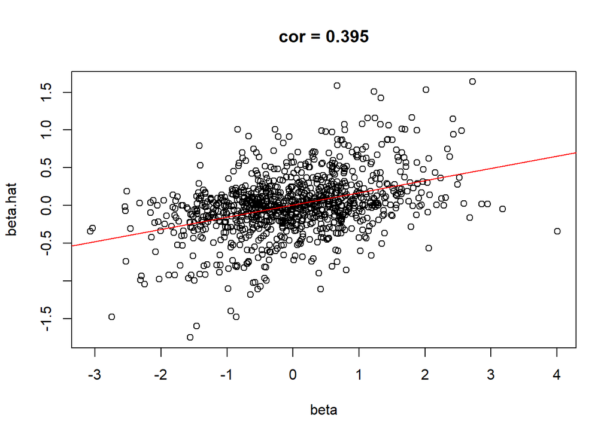

```r
plot(beta, beta.hat, main=paste0("cor = ", round(tmp, 3)))
abline(lm(beta.hat ~ beta), col="red")
```

```r
a.pred.train <- X[in.train,] %*% beta.hat # breeding values pop entrainement = valeurs génotypiques additives
(tmp <- cor(a[in.train], a.pred.train))
```

```
##      [,1]
## [1,] 0.89
```

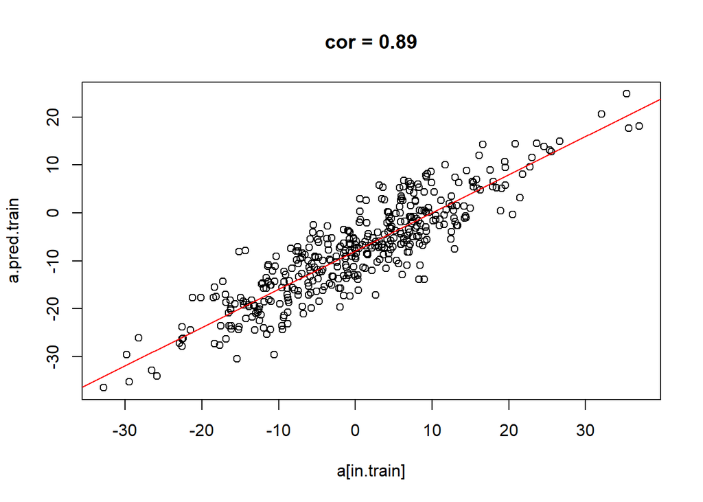

```r
plot(a[in.train], a.pred.train, main=paste0("cor = ", round(tmp, 3)))
abline(lm(a.pred.train ~ a[in.train]), col="red")
```

### 7.1.3 Test

Prédire les valeurs génotypiques sur l’ensemble de test à partir des effets alléliques estimés sur l’ensemble d’entraînement:

```r
a.pred.test <- X[in.test,] %*% beta.hat  # breeding values pop test
(tmp <- cor(a[in.test], a.pred.test)) # précision de prédiction ou predictive ability
```

```
##       [,1]
## [1,] 0.859
```

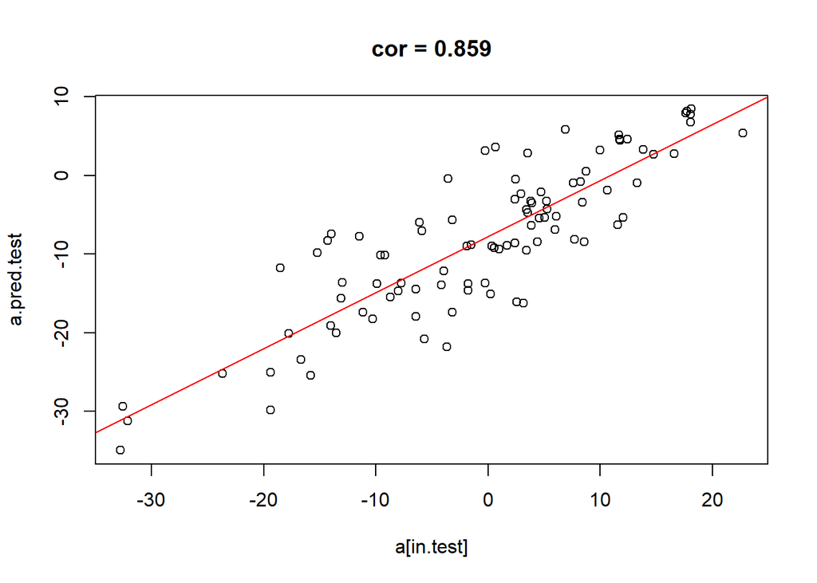

```r
plot(a[in.test], a.pred.test, main=paste0("cor = ", round(tmp, 3)))
abline(lm(a.pred.test ~ a[in.test]), col="red")
```

On obtient ici une valeur de précision de prédiction. Cette valeur peut varier selon les individus sélectionnés dans la population d’entraînement et de validation. C’est pourquoi, on fait de la validation croisée, en changeant plusieurs fois les populations d’entraînement et de validation.

## 7.2 Validation croisée

En pratique, on définit toutes les partitions pour que tous les individus fassent partie de la population de validation au moins une fois. On répète le processus plusieurs fois et on étudie les moyennes des précisions de prédiction sur toutes les partitions.

[figure not shown]

Schéma validation-croisée

La fonction `cvFolds` va permettre de définir les jeux d’entraînement et de validation de la validation croisée.

- K = 5 : nombre de partitions voulues, le jeu d’entraînement comportera alors 4/5e des individus
- R = 10 : nombre de fois que la validation croisée est répétée, à chaque fois on rééchantillonne des individus différents dans les populations d’entraînement et de validation.

```r
folds <- cvFolds(n=nrow(X), K=5, R=10)
dim(folds$subsets)
```

```
## [1] 500  10
```

A la fin nous aurons donc 50 valeurs de précision de prédiction, correspondant à 50 ajustements du modèle, c’est ce que fait la boucle suivante.

```r
out.cv <- expand.grid(K=seq(folds$K), R=seq(folds$R))
out.cv$PA <- NA
for(r in 1:folds$R){
  for(k in 1:folds$K){
    ## in.tst = set de validation
    in.tst <- rownames(X)[folds$subsets[,r][folds$which == k]]
    ## in.train = set d'entrainement
    in.train <- setdiff(rownames(X),in.tst)
    ## ajustement du modèle
    fit <- rrBLUP::mixed.solve(y=y[in.train,],Z=X[in.train,])
    ## prédiction sur la population de validation
    pred <-  X[in.tst,] %*% as.matrix(fit$u)
    ## calcul de la précision de prédiction
    out.cv[out.cv$K == k & out.cv$R == r,"PA"] <- cor(pred,y[in.tst,])
  }
}
out.cv
```

```
##    K  R    PA
## 1  1  1 0.727
## 2  2  1 0.695
## 3  3  1 0.643
## 4  4  1 0.757
## 5  5  1 0.573
## 6  1  2 0.711
## 7  2  2 0.741
## 8  3  2 0.670
## 9  4  2 0.676
## 10 5  2 0.728
## 11 1  3 0.697
## 12 2  3 0.762
## 13 3  3 0.692
## 14 4  3 0.578
```

[output cut: 36 more lines]

```r
mean(out.cv$PA)
```

```
## [1] 0.682
```

```r
sd(out.cv$PA)
```

```
## [1] 0.0524
```

A vous de jouer ! Modifiez les paramètres par défauts et mesurez leur impact sur la précision de prédiction. Vous choisirez une représentation graphique qui illustrera vos conclusions.

# 8 Annexe

```r
t1 <- proc.time(); t1 - t0
```

```
## utilisateur     système      écoulé
##       84.70        9.23       94.84
```